# Exploring Ethnic Disparities and Social Dynamics: A Comprehensive Analysis of the UK Census Snapshot Dataset

Author

Onyedika Aralu

# 1 Introduction

An investigation into the UK census snapshot dataset is undertaken to derive insights, leveraging R programming tools. Commencing with the importation of essential packages such as ggplot(Wickham 2016) for visualisation, tidyverse(Wickham et al. 2019) to better transform and present our data, various other packages were were utilised. The project involves an initial exploration of the dataset. R programming serves as a crucial tool, facilitating a profound grasp of the science of data and augmenting analytical capabilities(Crawley 2012).

```r
library(tidyverse)
library(ggplot2)
library(skimr)
library(scales)
library(ggthemes)
```

```r
fd <- read_csv('/Users/mac/Desktop/Liam_data/data-1.csv')
```

# 2 Data Pre-processing

Initiating various procedures in R to prepare our dataset for analysis, it was observed that approximately 6100 observations contained null values. To address this issue, pre-processing algorithms in R will be employed. Additionally, both dbl columns, namely `H8` and `Female`, were transformed into factors due to their categorical nature. Also `Highest Ed` feature will be renamed properly for easy use. It is noteworthy that most missing values are associated with individuals aged 14 years and below.

```r
nulls<- fd[rowSums(is.na(fd)) > 0, ]
df <- fd |> rename(Highest_Ed = `Highest Ed`) |> mutate(Female= factor(Female), H8 = factor(H8))
fixed <- df |> filter(Age <= 14) |>
  mutate(Mar_Stat = ifelse(is.na(Mar_Stat), "Never married", Mar_Stat),
         INC = ifelse(is.na(INC), 0, INC ), Highest_Ed=ifelse(is.na(Highest_Ed),"Less than SecondarySchool",Highest_Ed))
norm <-df |> filter(Age > 14)
df_final <- bind_rows(fixed , norm) |> arrange(ID)
newdf <- df_final[complete.cases(df_final), ] # droping the remaininng null values
```

## 2.1 Feature engineering

Guided by the UK NHS publication on inclusive content https://service-manual.nhs.uk/content/inclusive-content/age, a new feature, `Age_Group`, is created from the existing Age feature. Simultaneously, the generation of `income_distribution` within common income brackets provides additional insights into this census data.

```r
newdf <- newdf |>
  mutate(Age_Group = case_when(Age >= 1 & Age <= 3 ~ "toddler", Age >= 4 & Age <= 12 ~ "Child",Age >= 13 & Age <= 19 ~ "Teenager",
                               Age >= 19 & Age <= 64 ~ "Adult", Age > 64 ~ "Older People", TRUE ~ "Infant"))
```

```r
income_breaks <- c(-Inf, 0, 15000, 24000, 45000, 60000, Inf)
income_labels <- c("No Income","Very Low", "Low", "Medium", "High", "Very High")
newdf$Income_distribution <- cut(newdf$INC, breaks = income_breaks, labels = income_labels, include.lowest = TRUE)
```

# 3 Exploratory Analysis

A quick dive into this dataset indicated A discernible inclination towards ethnic diversity, aligning with public accessible information that highlights the UK as one of the top countries with favorable migrant policies(Vargas-Silva 2014). This recognition intensifies our curiosity to delve into the trends and treatments of ethnic minority and its populations. The objective is to comprehend the dynamics among major and minor ethnic groups, enabling informed decision-making and discussions related to migration to the United Kingdom based on this census snapshot data. Evaluating the experiences of migrants over time, as depicted in this census, is pivotal for gauging the country’s appeal and reception to individuals from diverse backgrounds.

## 3.1 Income Distribution by Ethnicity

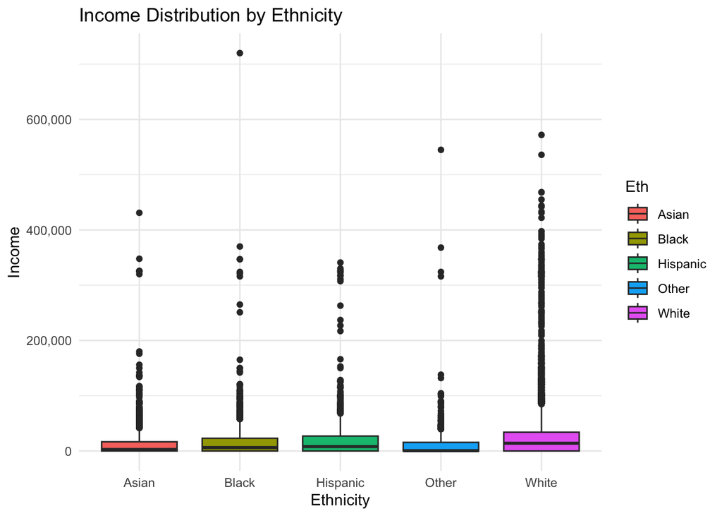

```r
ggplot(newdf, aes(x = Eth, y = INC, fill = Eth)) +
  geom_boxplot() + labs(title = "Income Distribution by Ethnicity", x = "Ethnicity", y = "Income") +
  theme_minimal()+ scale_y_continuous(labels = scales::comma)
```

Visualising the income distribution by ethnicity reveals that the `white` ethnic group, considered the major ethnic population in this context, tends to have the highest income, which aligns with the majority demographic of the country. However, intriguingly, the analysis shows that three other prominent ethnicities—`Hispanic`, `Black`, and `Asian`—also exhibit a decent income distribution. Notably, among these, the highest earners emerge from the `Black` ethnicity, offering a surprising finding in a predominantly white-dominated country. Further exploration will delve into factors such as the Highest Education level to better understand the underlying dynamics influencing these income trends. Additional analyses aim to uncover deeper insights within these demographic features.

## 3.2 Exploring Influences on Highest Earner: Education, Age and Marital Status Analysis

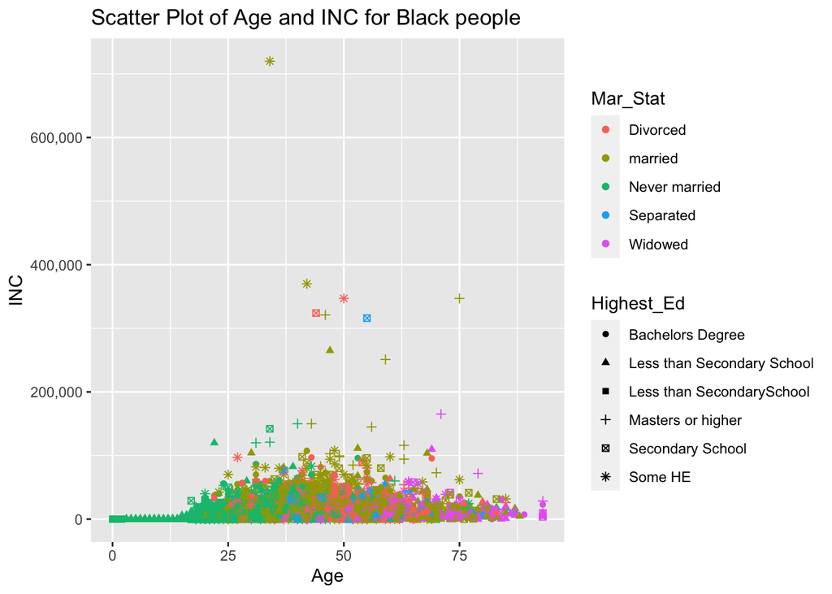

```r
Blacks <- newdf|> filter(Eth == 'Black')
ggplot(data = Blacks, mapping = aes(x = Age, y =INC))+
  geom_point(aes(color = Mar_Stat, shape = Highest_Ed))+ scale_y_continuous(labels = comma) +
  labs(title = "Scatter Plot of Age and INC for Black people",x = "Age",y = "INC")
```

Exploring influences on high earnings, An Analysis of `Age`, `Highest Education`, and `Marital Status` Impact on Income within the `Black` Ethnicity Reveals Intriguing Patterns. The visualisation highlights that, to attain an income significantly above average in this country, individuals from the `Black` ethnicity are more likely to benefit from pursuing a master’s degree. However, it is noteworthy that our top earner who is from this ethnicity had attained only a moderate level of higher education, falling short of completing a bachelor’s degree or higher. Additionally, the individual was married and belonged to the age group of 25 to 40, categorized as `Adult` during the pre-processing stage.

## 3.3 Income Dynamics: Visualising Marital Status Impact on Average Earnings.

It is observed in our investigation on the highest earning within the `Black` demography, where the highest earner in our dataset originated, that there is no discernible impact or influence from Marital Status. This has sparked curiosity to examine the distribution of income concerning marital status on average.

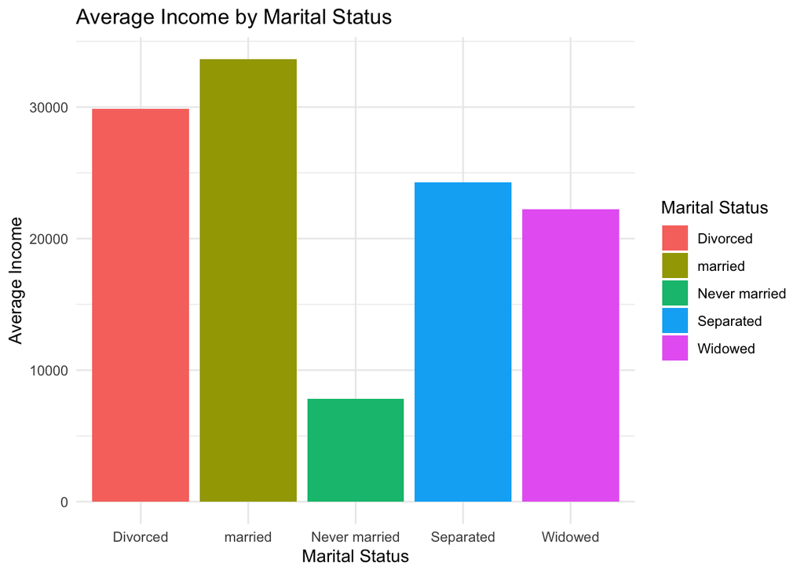

```r
average_income_by_marital_status <- newdf |>
  group_by(Mar_Stat) |> summarize(Average_Income = mean(INC, na.rm = TRUE))
ggplot(average_income_by_marital_status, aes(x = Mar_Stat, y = Average_Income, fill = Mar_Stat)) +
  geom_bar(stat = "identity") +
  labs(title = "Average Income by Marital Status",x = "Marital Status",y = "Average Income", fill = "Marital Status") +
  theme_minimal()
```

The data illustrates that individuals in the `married` demographic tend to achieve higher average earnings compared to those with other marital statuses. Notably, individuals who are `divorced`, `separated`, or `widowed` exhibit intriguing indications of good income dynamics. Conversely, those who have never been married display considerably lower average income. This observation aligns with expectations, as this group is predominantly comprised of individuals in the early life stages, categorized as `babies`, `toddlers`, and `teenagers`, as identified during the pre-processing stage. To further back this finding up and its relationship with `Age`, an Age distribution plot based on the marital status will be visualised to further comprehend the Average income insights above.

## 3.4 Age Distribution by Marital Status and Ethnicity

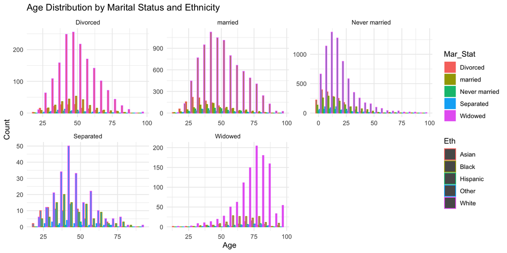

```r
ggplot(newdf, aes(x = Age, fill = Mar_Stat, color = Eth)) +
  geom_histogram(binwidth = 5, position = "dodge") +
  labs(title = "Age Distribution by Marital Status and Ethnicity", x = "Age", y = "Count") +
  facet_wrap(~Mar_Stat, scales = "free") + theme_minimal()
```

Although this may not provide a distinct insight, one can observe the facet of the `widowed` population and how it is negatively skewed, primarily due to the majority falling within the age range of 60 and above.

We adopt an alternative method to visualise this for deeper insights by leveraging our created feature, `Age_group`. We exclude the predominant demographic, which is the `white` ethnicity, to obtain a more meaningful representation of migrant ethnicities.

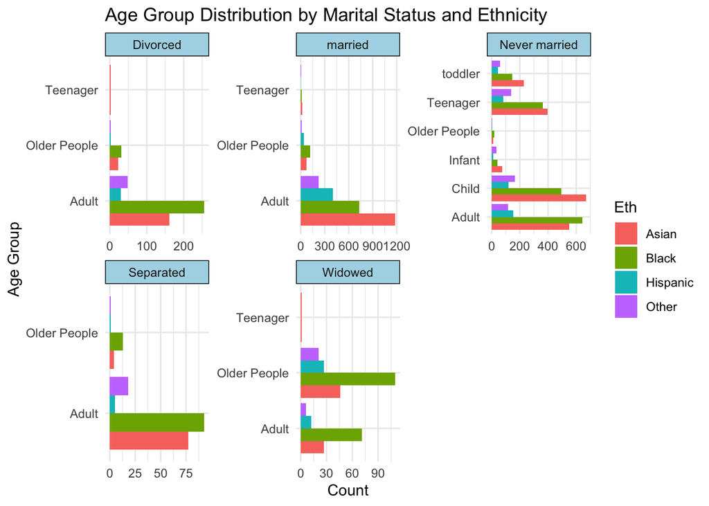

```r
migrants <- filter(newdf, Eth != "White")
ggplot(migrants, aes(y= Age_Group, fill = Eth)) +
  geom_bar(position = "dodge") +
  labs(title = "Age Group Distribution by Marital Status and Ethnicity", x = "Count", y = "Age Group") +
  facet_wrap(~Mar_Stat, scales = "free") + theme_minimal()+
  theme(strip.background = element_rect(fill = "lightblue", color = "black"))
```

## 3.5 Average Income by Number of People in Households

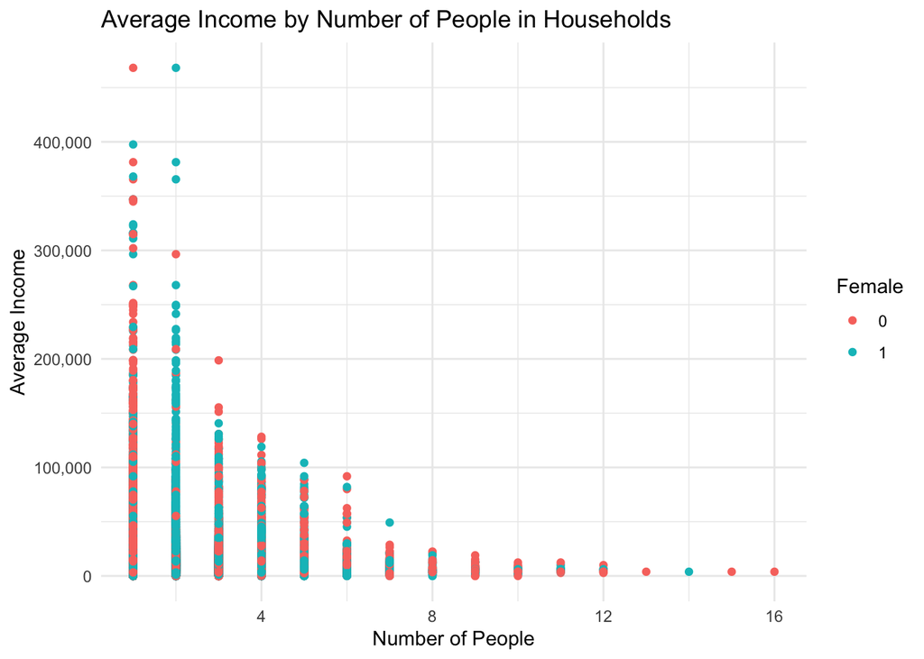

```r
avgincome_by_household <- newdf |>
  group_by(ID) |> mutate(Average_Income = mean(INC, na.rm = TRUE))
avgincome_by_household |>
  ggplot(aes(x = Person_ID, y = Average_Income, color = as.factor(Female))) +
  geom_point() +
  scale_y_continuous(labels = comma)+
  labs(title = "Average Income by Number of People in Households",
       x = "Number of People", y = "Average Income", color = "Female") +theme_minimal()
```

The graph clearly indicates that as the number of individuals in a household increases, the average income decreases. To delve deeper into this pattern, we will specifically analyse households with above 10 occupants to analyse factors influencing their relatively low income, exploring the potential role of Gender(`Female` or `non female`).

## 3.6 Exploring Large Households (Above 10 Occupants): Age and Income Distribution

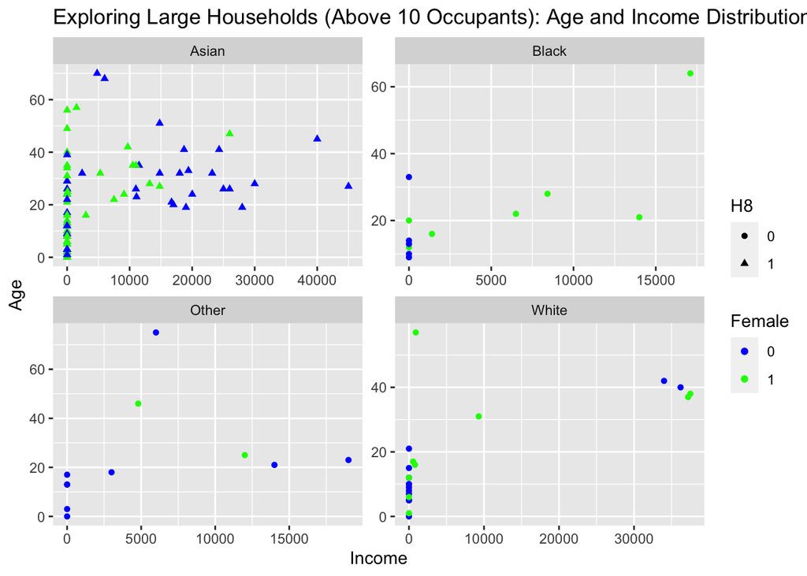

```r
household_size <- newdf |> group_by(ID) |> summarize(Household_Size = n_distinct(Person_ID))
pullid <- household_size|> filter(Household_Size > 10) |> pull(ID) # pull id of household > 10 people
household11up <- newdf |> filter(ID %in% pullid)
# lets now visualise based on this household and Create a scatter plot with facets
ggplot(household11up, aes(x = INC, y = Age, color = Female, shape=H8)) +
  geom_point() + facet_wrap(~Eth, scales = "free") +
  labs(title = "Exploring Large Households (Above 10 Occupants): Age and Income Distribution",
       x = "Income", y = "Age") + scale_color_manual(values = c("0" = "blue", "1" = "green"))
```

## 3.7 Average Income for all Households in our dataset

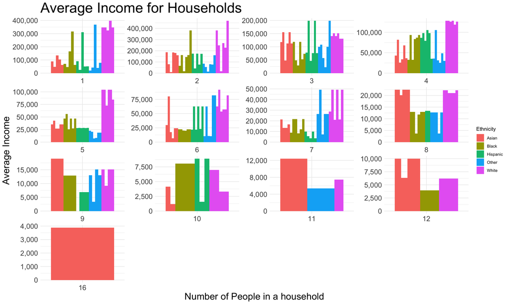

```r
comparison_data <- avgincome_by_household |>
  group_by(ID) |> summarize(Count = n_distinct(Person_ID))
# Filter data for the specified numbers of people
filtered_data <- comparison_data |>
  filter(Count >= 1 & Count <= 16) |> left_join(avgincome_by_household, by = "ID")
# Your ggplot code here
ggplot(filtered_data, aes(x = as.factor(Count), y = Average_Income, fill = Eth, shape = Highest_Ed)) +
  geom_bar(stat = "identity", position = "dodge") +
  facet_wrap(~Count, scales = "free") +  # Facet by the number of people
  labs(title = "Average Income for Households",x = "Number of People in a household",y = "Average Income",
       fill = "Ethnicity", shape = "Education") +
  scale_y_continuous(labels = scales::comma) + theme_minimal() +
  theme(strip.placement = "outside", strip.text = element_blank(),
        axis.title.x = element_text(size = 20),axis.title.y = element_text(size = 20),
        axis.text.x = element_text(size = 15),axis.text.y = element_text(size = 15),plot.title = element_text(size = 30) )
```

# 4 Conclusion

## References

Crawley, Michael J. 2012. “The r Book,” November. https://doi.org/10.1002/9781118448908.

Grillo, Ralph, ed. 2008. “The Family in Question : Immigrant and Ethnic Minorities in Multicultural Europe.” https://doi.org/10.5117/9789053568699.

Vargas-Silva, Carlos. 2014. “Highly Skilled Migrant Workers and the UK Business Cycle.” *Population, Space and Place* 22 (5): 457–70. https://doi.org/10.1002/psp.1867.

Wickham, Hadley. 2016. “Ggplot2: Elegant Graphics for Data Analysis.” https://ggplot2.tidyverse.org.

Wickham, Hadley, Mara Averick, Jennifer Bryan, Winston Chang, Lucy D’Agostino McGowan, Romain François, Garrett Grolemund, et al. 2019. “Welcome to the Tidyverse” 4: 1686. https://doi.org/10.21105/joss.01686.